# Week 5 / Lab 03: Prostate cancer $t$-tests, Shakespeare, and parallelization

AG Schissler

Monday September 23, 2019

## I. Opening

### Start-of-class work

1. Log in the your workstation.
2. Open the RStudio application on your machine.
3. Open lesson8_ttests_text_parallel.Rmd from website so that you can work along the lecture.
4. Open lab_03_ttest_text_parallel.Rmd to have the lab available for review.

### This week’s agenda

This week we’ll go deeper into the prostate cancer data set while reviewing inferential statistical tests, practice text manipulation during an analysis Shakespeare’s works, and use the `parallel` package to make use of multi-core processes.

### Today learning outcomes

Students will be able to

- conduct routine statistical inference using built-in R functions.
- manipulate text data.
- parallelize code for efficient processing.

## II. Using $t$-tests to infer prostate cancer population differences

At the end of Lab 02, you calculated sample means and standard deviations for the two `svi` groups. These quantatities may suggest that the group population means differ for some variable(s). In Lab 03, we’ll formally test whether the population means differ using statistical inference.

Recall that the **two-sample (unpaired) t-statistic** between data sets $X=(X_1,\ldots,X_n)$ and $Y=(Y_1,\ldots,Y_m)$ is:
$$T = \frac{\bar{X} - \bar{Y}}{\sqrt{\frac{s_X^2}{n} + \frac{s_Y^2}{m}}},$$
where $\bar{X}=\sum_{i=1}^n X_i/n$ is the sample mean of $X$, $s_X^2 = \sum_{i=1}^n (X_i-\bar{X})^2/(n-1)$ is the sample variance of $X$, and similarly for $\bar{Y}$ and $s_Y^2$.

The **degrees of freedom** associated with $T$ is:
$$\nu = \frac{(\frac{s_X^2}{n}+\frac{s_Y^2}{m})^2}{\frac{(\frac{s_X^2}{n})^2}{n-1} +
\frac{(\frac{s_Y^2}{m})^2}{m-1}}.$$

## III. Manipulating and analyzing Shakespeare texts

### Shakespeare’s complete works

[Project Gutenberg](http://www.gutenberg.org) offers over 50,000 free online books, especially old books (classic literature), for which copyright has expired. We’re going to look at the complete works of [William Shakespeare](https://en.wikipedia.org/wiki/William_Shakespeare), taken from the Project Gutenberg website.

To avoid hitting the Project Gutenberg server over and over again, I point you to text file that contains the complete works of William Shakespeare, located [here](http://www.stat.cmu.edu/~ryantibs/statcomp/data/shakespeare.txt). Skim through this text file a little bit to get a sense of what it contains (a whole lot!).

Lab 03 will walk you through all analysis of this file. Including more motivation of the function `get_wordtab_from_url` described in the lecture 06_functions_lab02.html.

## IV. Using the `parallel` package

We’ll use the `parallel` package to accelerate some simulation.

Let’s discuss this post from the excellent forum, [Stack Overflow](https://stackoverflow.com/):  
https://stackoverflow.com/questions/19281010/simplest-way-to-do-parallel-replicate.

### Serial (one-thread) replicate example

```r
## simreps is the number of simulation reps (n)
simreps <- 1e5 ## this is 100000, five zeros
## ?replicate
set.seed(44)
compute_meanSDratio <- function(x) {
    mean(x)/sd(x)
}
system.time(res0 <- replicate(n = simreps, expr = compute_meanSDratio( rnorm(10) )))
```

```
##    user  system elapsed
##   3.803   0.023   3.830
```

```r
str(res0)
```

```
##  num [1:100000] -0.5801 0.2142 -0.0969 0.2555 0.2227 ...
```

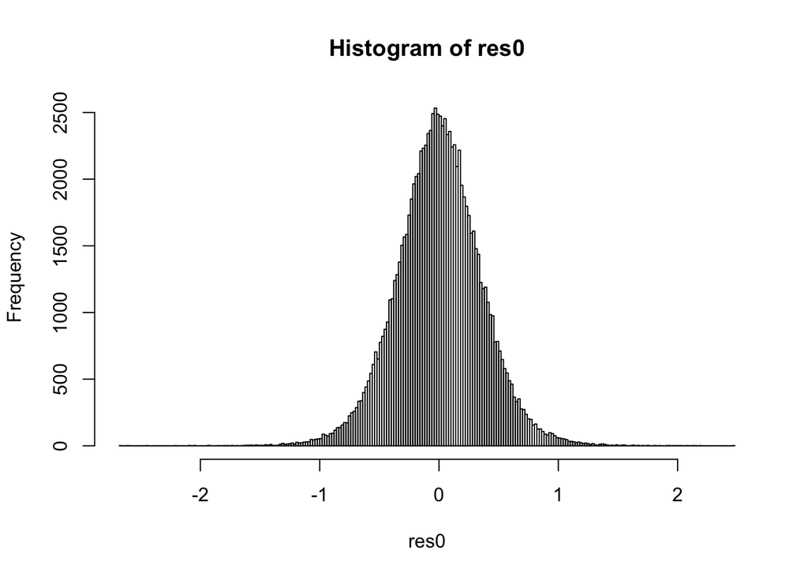

```r
hist(res0, breaks = "scott")
```

### parallelized replicate function version 1

```r
#create cluster
library(parallel)
cl <- makeCluster(detectCores()-1)
# get library support needed to run the code
## clusterEvalQ(cl,library(MASS))
# put objects in place that might be needed for the code
## myData <- data.frame(x=1:10, y=rnorm(10))
## clusterExport(cl,c("myData"))
# Set a different seed on each member of the cluster (just in case)
clusterSetRNGStream(cl)
##... then parallel replicate...
## on-the-fly function definition
system.time(res1 <- parSapply(cl, 1:simreps, function(i,...) { x <- rnorm(10); mean(x)/sd(x) } ))
```

```
##    user  system elapsed
##   0.045   0.006   1.042
```

```r
str(res1)
```

```
##  num [1:100000] 0.0436 -0.4386 0.4014 -0.4011 -0.0711 ...
```

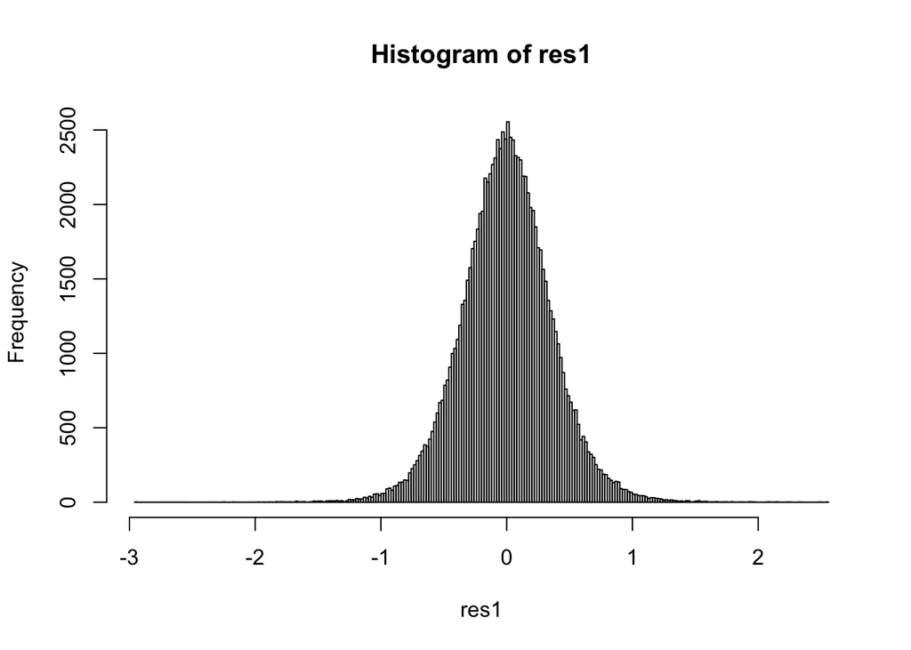

```r
hist(res1, breaks = "scott")
```

### Version two

```r
parReplicate <- function(cl, n, expr, simplify=TRUE, USE.NAMES=TRUE)
  parSapply(cl, integer(n), function(i, ex) eval(ex, envir=.GlobalEnv),
            substitute(expr), simplify=simplify, USE.NAMES=USE.NAMES)
## export functions/objects to the cores
clusterExport(cl,c("compute_meanSDratio", "simreps"))
system.time(res2 <- parReplicate(cl, simreps, compute_meanSDratio(x = rnorm(10))))
```

```
##    user  system elapsed
##   0.045   0.006   1.076
```

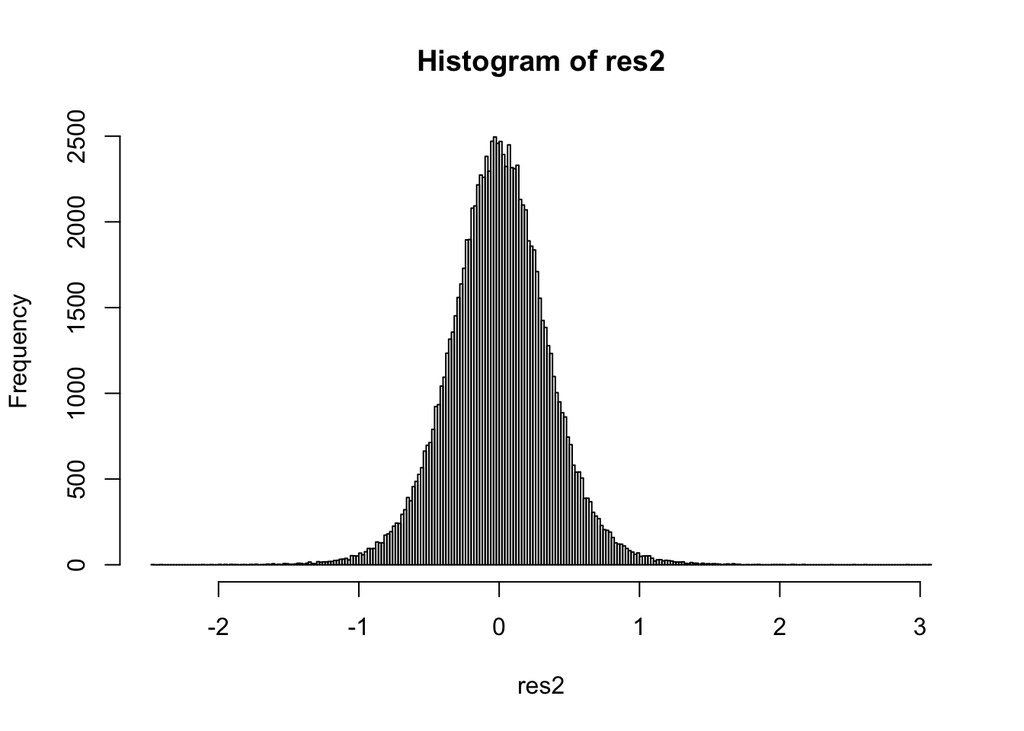

```r
hist(res2, breaks = "scott")
```

Always stop the cluster.

```r
## stop the cluster
stopCluster(cl)
```

## Please work on lab 03 with any remaining time

## V. Summary

- Why is the degrees of freedom for a t-test with unequal variances so complicated?
- Why paralellize?
- What additional difficulties arise when parallelizing?